# Ceny zakupu nieruchomości_czerwiec 2024

2025-11-27

# Wstęp

Rynek nieruchomości jest jednym z najważniejszych sektorów polskiej gospodarki, decyduje o możliwościach zakupu mieszkania przez Polaków, atrakcyjności inwestycji oraz kondycji całej branży budowlanej. W 2024 roku, dzięki stabilizacji stóp procentowych, rosnącym płacom i niskiej inflacji, zdolność kredytowa gospodarstw domowych wyraźnie się poprawiła. Niniejszy projekt koncentruje się wyłącznie na danych z czerwca 2024 roku, dzięki czemu pozwala dokładnie uchwycić aktualny poziom cen tuż po okresie dynamicznych wzrostów z poprzednich miesięcy.

## Pytania badawcze

1. Jak kształtują się **średnie ceny** mieszkań w 15 największych miastach Polski?
2. Które miasta charakteryzują się **najwyższymi**, a które **najniższymi** **cenami** za metr kwadratowy?
3. W jaki sposób **powierzchnia** mieszkania wpływa na jego cenę całkowitą oraz cenę za metr kwadratowy?
4. Jak **odległość od centrum** miasta wpływa na poziom cen mieszkań?
5. W jaki sposób **stan techniczny** mieszkania przekłada się na jego wartość rynkową?
6. Jakie znaczenie mają **udogodnienia**, takie jak balkon, winda czy miejsce parkingowe, dla poziomu ceny ofertowej?
7. Jak **typ budynku** wpływa na poziom cen?
8. Jakie są różnice w cenach mieszkań w zależności od **liczby pokoi**?

# Opis danych

Zbiór danych zawiera **miesięczną kolekcję ofert sprzedaży z czerwca 2024 roku z 15 największych polskich miast**.

# Analiza danych

## Braki danych

```r
procent <- prop_complete(dane_nieruchomosci) * 100
```

w danych znajduje się 93.6896623 % kompletnych wartości.

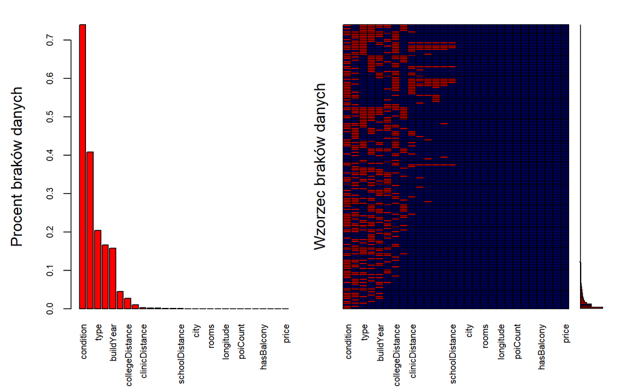

```
##
##  Variables sorted by number of missings:
##              Variable        Count
##             condition 0.7404771871
##      buildingMaterial 0.4089112134
##                  type 0.2045021162
##                 floor 0.1661783173
##             buildYear 0.1572019906
##           hasElevator 0.0446490861
##       collegeDistance 0.0271615274
##            floorCount 0.0097204781
##        clinicDistance 0.0029300963
##    restaurantDistance 0.0014417934
##      pharmacyDistance 0.0013952839
##    postOfficeDistance 0.0009301893
##  kindergartenDistance 0.0008836798
##        schoolDistance 0.0005116041
##                    id 0.0000000000
##                  city 0.0000000000
##          squareMeters 0.0000000000
##                 rooms 0.0000000000
##              latitude 0.0000000000
##             longitude 0.0000000000
##        centreDistance 0.0000000000
##              poiCount 0.0000000000
##             ownership 0.0000000000
##       hasParkingSpace 0.0000000000
##            hasBalcony 0.0000000000
##           hasSecurity 0.0000000000
##        hasStorageRoom 0.0000000000
##                 price 0.0000000000
```

```r
VIM::aggr(dane_nieruchomosci, col=c('navyblue','red'), numbers=TRUE, sortVars=TRUE, labels=names(dane_nieruchomosci), cex.axis=.7, gap=3, ylab=c("Procent braków danych","Wzorzec braków danych"))
```